Purpose: After creating a consensus file with `02-merge_callers.R`, this notebook plots these data in a series of plots to compare the consensus calls to the individual callers.

### Summary of Findings:

#### Individual Caller’s Reports

*Notable Findings:*

- VarDict calls more mutations than any of the other callers. Many of these have very low suggesting that some may be sequencing errors.
- Mutect2, Strelka2, and Lancet do have plenty of mutations in common.

### Outline of analyses completed:

- Upset graph
- VAF of combinations of callers
- Base changes by caller
- VAF distributions by caller
- VAF correlations between callers

#### Usage

To run this from the command line, use:

```
Rscript -e "rmarkdown::render('analyses/snv-callers/compare_snv_callers_plots.Rmd',
                              clean = TRUE)"
```

*This assumes you are in the top directory of the repository.*

## Setup

#### Packages and functions

Read in set up script.

```r
# Magrittr pipe
`%>%` <- dplyr::`%>%`
```

Set up directories.

```r
scratch_dir <- file.path("..", "..", "scratch")
results_dir <- file.path("results", "comparison")
plots_dir <- file.path("plots", "comparison")

if (!dir.exists(results_dir)) {
  dir.create(results_dir)
}
if (!dir.exists(plots_dir)) {
  dir.create(plots_dir)
}
```

```r
upset_plot <- function(callers_per_mutation_df) {
callers_per_mutation_df %>%
  dplyr::group_by(caller_combo) %>%
  dplyr::tally() %>%
  ggplot2::ggplot(ggplot2::aes(x = reorder(caller_combo, -n), y = n)) +
  ggplot2::geom_bar(
        position = "dodge", stat = "identity") +
  ggplot2::theme_classic() +
  ggupset::scale_x_mergelist(sep = "-") +
  ggupset::axis_combmatrix(sep = "-") +
  ggplot2::xlab("") +
  ggplot2::ylab("")
}
```

## Connect to database

Connect to SQLite database.

```r
# Start up connection
con <- DBI::dbConnect(RSQLite::SQLite(),
                      file.path(scratch_dir, "snv_db.sqlite"))
```

Note what columns we will join by.

```r
join_cols = c("Chromosome",
              "Start_Position",
              "Reference_Allele",
              "Allele",
              "Tumor_Sample_Barcode",
              "Variant_Classification")
```

Set up tables from the database but only call the columns we need.

```r
strelka <- dplyr::tbl(con, "strelka") %>%
  dplyr::select(join_cols, "VAF")

lancet <- dplyr::tbl(con, "lancet") %>%
  dplyr::select(join_cols, "VAF")

mutect <- dplyr::tbl(con, "mutect") %>%
  dplyr::select(join_cols, "VAF")

vardict <- dplyr::tbl(con, "vardict") %>%
  dplyr::select(join_cols, "VAF")
```

Because `DBI` does not support full_join, we had to use a series of `left_join` and `union_all` calls in order to get a full join of all the callers.

```r
# This script will do the full join of the data for us
source(file.path("util", "full_join_callers.R"))

# Bring out the data.frame
all_caller_df <- all_caller %>%
  as.data.frame

# Take a peek at what this looks like
head(all_caller_df)
```

```
##   Chromosome Start_Position Reference_Allele Allele Tumor_Sample_Barcode
## 1       chr1       20428534                C      T          BS_VVD8TJNE
## 2       chr1       49753254                G      A          BS_VVD8TJNE
## 3       chr1       51082946                C      T          BS_VVD8TJNE
## 4       chr1       52162106                G      A          BS_VVD8TJNE
## 5       chr1       59017757                C      T          BS_VVD8TJNE
## 6       chr1       68110354                T      C          BS_VVD8TJNE
##   Variant_Classification VAF_lancet VAF_strelka VAF_vardict VAF_mutect
## 1                 Intron 0.13924051   0.1789474   0.1789474  0.1808511
## 2                 Intron 0.13265306   0.1359223   0.1359223  0.1300000
## 3                    IGR 0.14754098   0.1714286   0.1571429  0.1594203
## 4                 Intron 0.09259259          NA          NA         NA
## 5                 Intron 0.34177215   0.3370787   0.3448276         NA
## 6                 Intron 0.10389610   0.1204819   0.1204819  0.1204819
```

```r
# Set up the data as a data.frame
vaf_df <- all_caller_df %>%
  dplyr::select("VAF_lancet", "VAF_strelka", "VAF_vardict", "VAF_mutect",
                "Variant_Classification") %>%
  dplyr::mutate(VAF_consensus = VAF_strelka)

# Determine which mutations are part of the consensus
consensus_index <- vaf_df %>%
  dplyr::select(-c(VAF_vardict, VAF_consensus, Variant_Classification)) %>%
  rowSums(is.na(.)) > 0

# Make non consensus VAF into an NA
vaf_df$VAF_consensus[consensus_index] <- NA

# Make this long form for plotting and
long_vaf_df <- vaf_df %>%
  dplyr::mutate(index = factor(1:nrow(.))) %>%
  tidyr::gather(key = "caller", value = "vaf", -index, -Variant_Classification) %>%
  dplyr::mutate(caller = gsub("VAF_", "", caller)) %>%
  dplyr::filter(!is.na(vaf))
```

Get median vaf for each mutation with each caller combination.

```r
# Take out the consensus VAF for this combination
long_caller_df <- long_vaf_df %>%
  dplyr::filter(caller != "consensus")

# Determine the combination of callers for each mutation
callers_per_mutation <- tapply(
    long_caller_df$caller,
    long_caller_df$index,
    paste0,
    collapse = "-"
  ) %>%
  as.data.frame() %>%
  tibble::rownames_to_column("index")

# Determine Median VAF for each mutation
vaf_med <- tapply(
    long_caller_df$vaf,
    long_caller_df$index,
    median
  ) %>%
  as.data.frame() %>%
  tibble::rownames_to_column("index")

# Join the median VAF and the callers that call that mutation into one data.frame
callers_per_mutation <- callers_per_mutation %>%
  dplyr::inner_join(vaf_med, by = "index") %>%
  dplyr::left_join(long_caller_df %>%
                      dplyr::select(Variant_Classification, index),
                   by = "index") %>%
  # Make column names more sensible
  dplyr::rename(caller_combo = "..x", median_vaf = "..y")
```

## Upset graph

Make the upset plot.

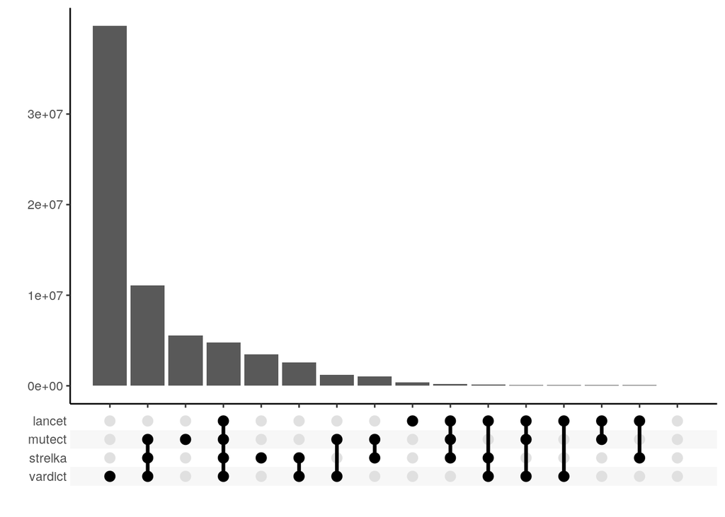

```r
upsettr_plot <- callers_per_mutation %>%
  upset_plot()

# Print this out here
upsettr_plot
```

Save this plot to a png

```r
# We can save the plot like a normal ggplot
png(file = file.path(plots_dir, "upset_plot.png"))
upsettr_plot
dev.off()
```

Transcripts only upset plot.

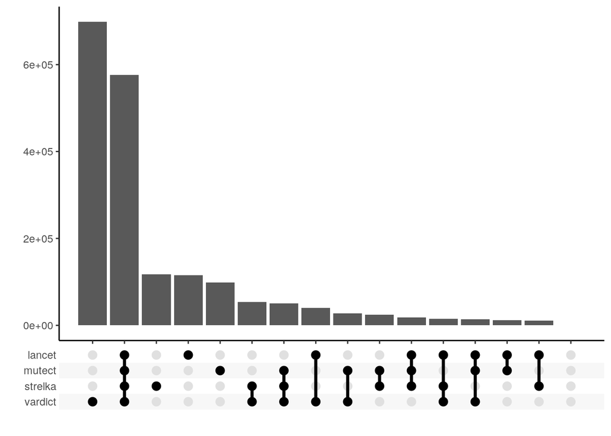

```r
callers_per_mutation %>%
  dplyr::filter(!(Variant_Classification %in% c("5'Flank", "3'Flank", "IGR", "Intron"))) %>%
  upset_plot()
```

Non transcript upset plot.

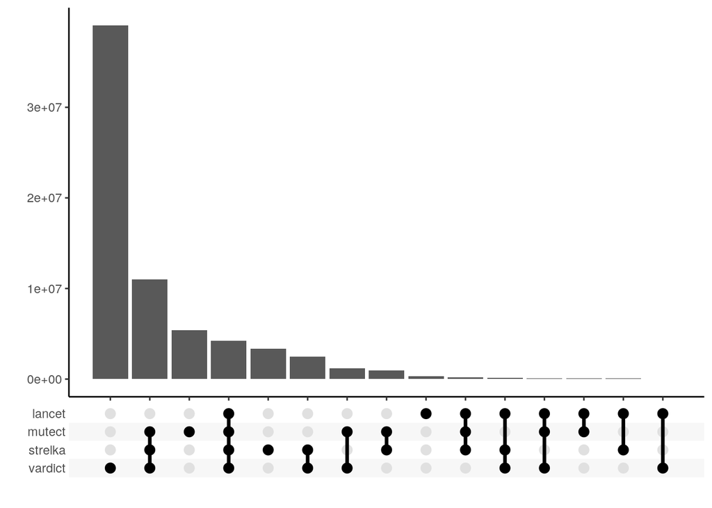

```r
callers_per_mutation %>%
  dplyr::filter(Variant_Classification %in% c("5'Flank", "3'Flank", "IGR", "Intron")) %>%
  upset_plot()
```

## VAF for combination sets of callers

Graph mutations by combinations of callers and plot the VAF density. Get list of callers per mutation and the median vaf for each. Graph the median VAF for each combination of callers.

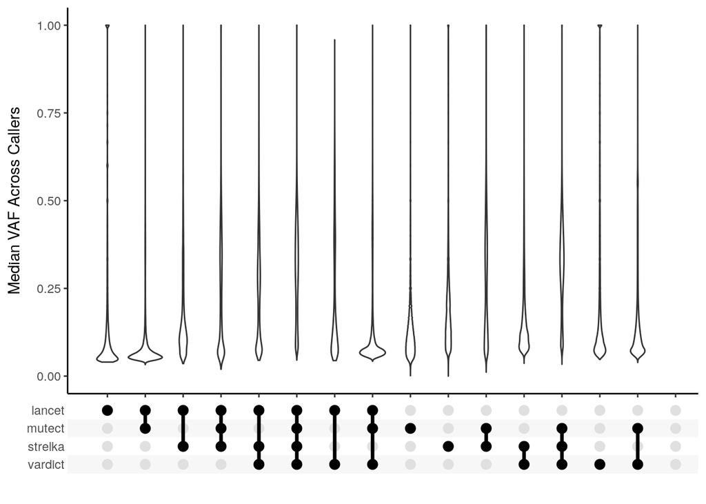

```r
# Make this plot
callers_per_mutation %>%
  ggplot2::ggplot(ggplot2::aes(x = caller_combo, y = median_vaf)) +
  ggplot2::geom_violin() +
  ggplot2::theme_classic() +
  ggupset::scale_x_mergelist(sep = "-") +
  ggupset::axis_combmatrix(sep = "-") +
  ggplot2::xlab("") +
  ggplot2::ylab("Median VAF Across Callers")
```

```r
# Save this plot
ggplot2::ggsave(file.path(plots_dir, "upset_median_vaf_plot.png"))
```

## Base Changes

Summarize base change information per caller.

```r
# Summarize by the number of times each base change shows up in each category.
perc_change_df <- all_caller_df %>%
  # Make change variable
  dplyr::mutate(base_change = paste0(Allele, ">", Reference_Allele)) %>%
  dplyr::mutate(
    # From the base_change variable, summarize insertions, deletions, and
    # changes that are more than one base into their own groups.
    change = dplyr::case_when(
      grepl("^-", base_change) ~ "ins",
      grepl("-$", base_change) ~ "del",
      nchar(base_change) > 3 ~ "long_change",
      TRUE ~ base_change
    )
  ) %>%
  # Whittle down to necessary columns
  dplyr::select(change, dplyr::starts_with("VAF_")) %>%
  # Make this long form
  tidyr::gather(key = "caller", value = "vaf", -change) %>%
  # Drop the prefix
  dplyr::mutate(caller = gsub("VAF_", "", caller)) %>%
  # Get rid of NA rows
  dplyr::filter(!is.na(vaf)) %>%
  # Summarize the number of mutations per caller
  dplyr::count(caller, change, name = "count") %>%
  dplyr::add_count(caller, wt = count) %>%
  # Calculate the percent of each
  dplyr::mutate(percent = count / n) %>%
  # Drop nonsensical change
  dplyr::filter(!grepl("N>*|*>N|C>C|T>T|A>A|G>G", change),
                !is.na(change)) %>%
  dplyr::mutate(
    change = as.factor(change),
    # Change factor level order so ins and del are at the end
    change = forcats::fct_relevel(change, "ins", "del", "long_change", after = Inf)
  )
```

Make a barplot illustrating the percent of the mutations for each caller that that are each type of change.

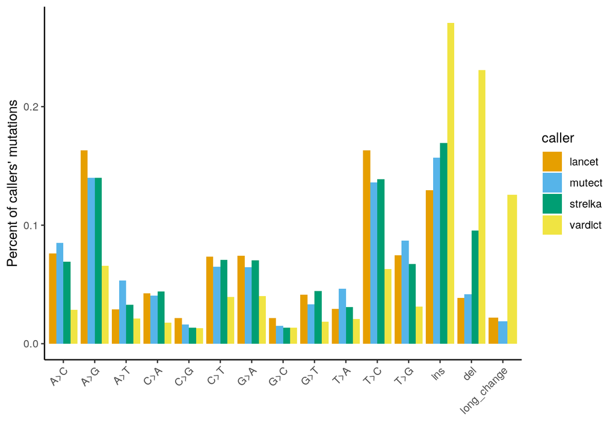

```r
perc_change_df %>%
  ggplot2::ggplot(ggplot2::aes(x = change, y = percent)) +
  ggplot2::theme_classic() +
  ggplot2::geom_bar(
    position = "dodge", stat = "identity",
    ggplot2::aes(fill = caller)
  ) +
  ggplot2::theme(axis.text.x = ggplot2::element_text(angle = 45, hjust = 1)) +
  ggplot2::xlab("") +
  ggplot2::ylab("Percent of callers' mutations") +
  colorblindr::scale_fill_OkabeIto()
```

```r
# Save this plot
ggplot2::ggsave(file.path(plots_dir, "perc_base_change_plot.png"))
```

## VAF distributions

Make a violin plot of each caller.

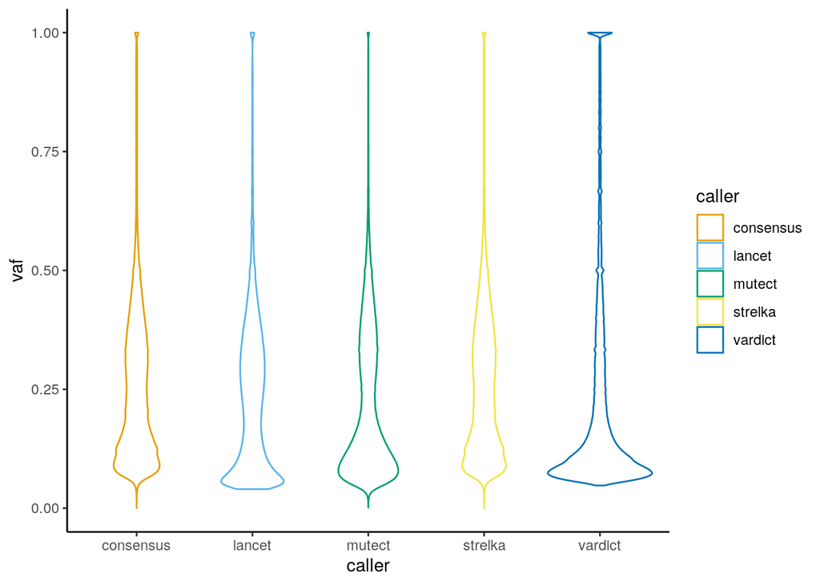

```r
long_vaf_df %>%
  ggplot2::ggplot(ggplot2::aes(x = caller, y = vaf, color = caller)) +
  ggplot2::geom_violin() +
  ggplot2::theme_classic() +
  colorblindr::scale_color_OkabeIto()
```

```r
# Save this plot
ggplot2::ggsave(file.path(plots_dir, "vaf_violin_plot.png"))
```

## VAF correlations

Correlate VAF’s across callers

```r
vaf_df %>%
  dplyr::select(-VAF_consensus, -Variant_Classification) %>%
  cor() %>%
  knitr::kable()
```

|  | VAF_lancet | VAF_strelka | VAF_vardict | VAF_mutect |
| --- | --- | --- | --- | --- |
| VAF_lancet | 1 | NA | NA | NA |
| VAF_strelka | NA | 1 | NA | NA |
| VAF_vardict | NA | NA | 1 | NA |
| VAF_mutect | NA | NA | NA | 1 |

## Mutation Region barplot

Summarize `Variant_Classification` information per caller.

```r
# Summarize by the number of times each base change shows up in each category.
perc_var_df <- long_vaf_df %>%
  # Summarize the number of mutations per caller
  dplyr::count(caller, Variant_Classification, name = "count") %>%
  dplyr::add_count(caller, wt = count) %>%
  # Calculate the percent of each
  dplyr::mutate(percent = count / n)
```

Make a barplot illustrating the percent of the mutations for each caller that that are each type of change.

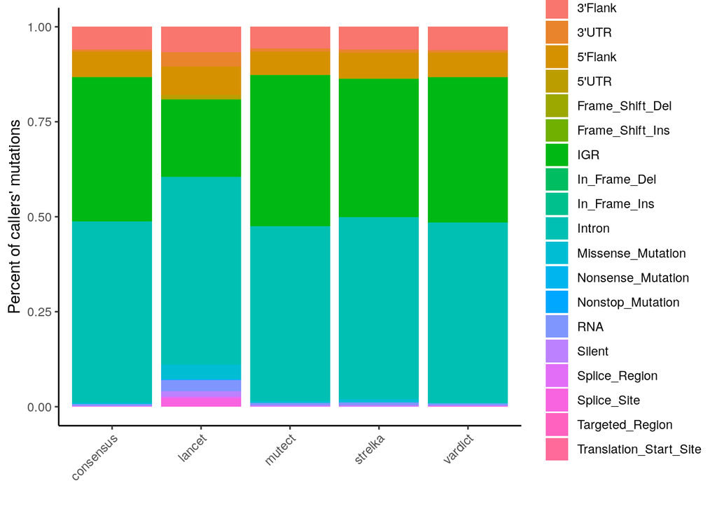

```r
perc_var_df %>%
  ggplot2::ggplot(ggplot2::aes(x = caller, y = percent)) +
  ggplot2::theme_classic() +
  ggplot2::geom_bar(
    position = "stack", stat = "identity",
    ggplot2::aes(fill = Variant_Classification)
  ) +
  ggplot2::theme(axis.text.x = ggplot2::element_text(angle = 45, hjust = 1)) +
  ggplot2::xlab("") +
  ggplot2::ylab("Percent of callers' mutations")
```

```r
# Save this plot
ggplot2::ggsave(file.path(plots_dir, "variant_classification_plot.png"))
```